# **MATH 3190 Homework 7**

Due March 26, 2026  
Focus: Notes 8  
Total Points: 90 + 10 (Self-Critique Comment and Uploading to GitHub) = 100

Note that your homework should be completed in Quarto. You can just add your answers and code to this document in the appropriate part. The file should be rendered as an html document or pdf document (html is quicker to render and you will need an installation of LaTeX to render as a pdf). You will “turn in” this homework by uploading the files, the .qmd and output file, to your GitHub `Math_3190_Assignment` repository in the `Homework/Homework_7` directory. Make sure all supporting files (if there are any) are in this directory as well. You should use `git` and `Unix` commands in a terminal for this (i.e. don’t manually upload files to GitHub). In addition, you will submit just your html or pdf file on Canvas to unlock the solutions.

Don’t forget to also put a self-critique comment on Canvas indicating what you did correctly and incorrectly and include any questions you may have about the assignment after submitting the assignment and thoroughly looking through the solutions.

# Problem 1 (57 points)

In Homework 6, we briefly looked at a small sample from this data set. Now we have the full data set with 20,640 districts. For districts in California from 1990, we want to predict the median house value for the district based on the district location (longitude and latitude), the median house age in the block group, the total number of rooms in the homes, the total number of bedrooms, the population in the district, the number of households, and the median income (in $10,000). These data were obtained from [scikit-learn.org](https://scikit-learn.org/stable/datasets.html) and can be found in the Data folder of the Math3190_Sp26 GitHub repo with the name `cal_housing.data`.

```r
library(math3190package)
library(caret)
library(GGally)
library(faraway)
library(pls)
library(umap)
```

### Part a (5 points)

Read in the data. The `read.csv()` function works for files that end in `.data` if they are comma separated like this file is. However, be aware that the housing data does not have column names, so make sure to put `header = FALSE`. Assign appropriate column names to the columns and then take logs (base e) of all variables except lat and long. Once this is done, split the data into training and testing sets with the testing containing 20% of the values. Set a seed when you do this.

```r
setwd("C:\\Users\\Samuel\\Desktop\\R-scripts-and-data\\MATH3190\\MATH3190-Assignments\\homework\\homework7")
data = read.csv("cal_housing.data", header = FALSE, col.names = c("Longitude","Latitude","MedianHouseAge","TotalRooms","TotalBedrooms","Population", "Households", "MedianIncome", "MedianHouseValue"))
housing = mutate(data, MedianHouseAge = log(MedianHouseAge), TotalRooms = log(TotalRooms), TotalBedrooms = log(TotalBedrooms), Population = log(Population), Households = log(Households), MedianIncome = log(MedianIncome), MedianHouseValue = log(MedianHouseValue))

set.seed(9000)
testing_index = createDataPartition(housing$MedianHouseValue,times = 1, p= 1/5, list = FALSE)
housingTest = housing[testing_index, ]
housingTrain = housing[-testing_index, ]
```

### Part b (5 points)

Use the following command to view pair-wise scatter plots for the data here. Change `housing_train` to whatever you called the training set and be sure to change the `eval` option for the code chunk to `true`. Note, that `lower` option changes the points to be plotted with periods instead of circles. This speeds up plotting time considerably and makes the plots more readable since there are many data points here.

Based on these plots, does multicollinearity appear to be an issue here? Explain.

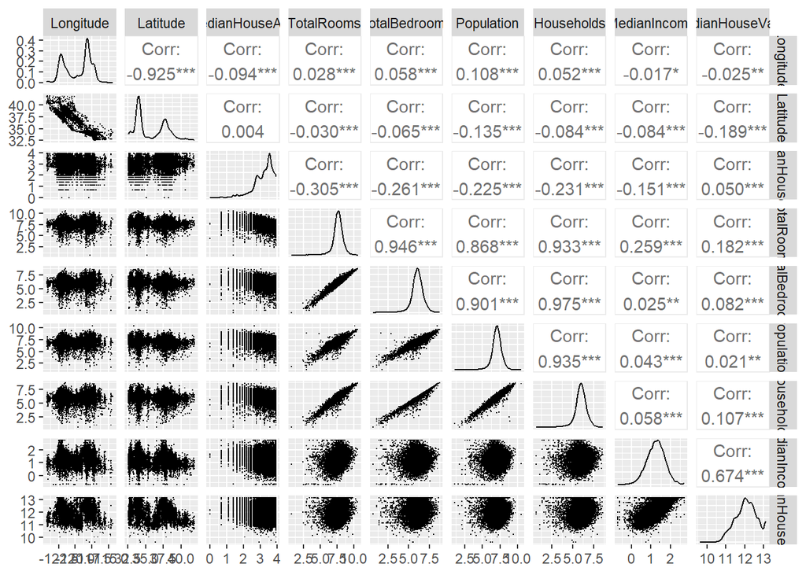

```r
ggpairs(housingTrain,
        lower = list(continuous = wrap("points", shape = "."))
)
```

Latitude and Longitude have a very high correlation. This will very likely cause multicolinearity issues in the future, and a principal component analysis may fix this. The same issue exists for total bedrooms, population, households, and total rooms.

### Part c (4 points)

Fit a OLS regression model predicting house prices from all other variables. Check its summary output and its VIF values. Comment on the VIFs.

```r
OLSmod = lm(MedianHouseValue ~ ., data = housingTrain)
summary(OLSmod)
```

```
Call:
lm(formula = MedianHouseValue ~ ., data = housingTrain)

Residuals:
     Min       1Q   Median       3Q      Max
-2.74712 -0.19180 -0.00243  0.18766  2.91563

Coefficients:
                Estimate Std. Error t value Pr(>|t|)
(Intercept)    -9.962344   0.344383 -28.928   <2e-16 ***
Longitude      -0.259983   0.003901 -66.650   <2e-16 ***
Latitude       -0.266875   0.003764 -70.894   <2e-16 ***
MedianHouseAge  0.066649   0.004927  13.527   <2e-16 ***
TotalRooms     -0.271162   0.016787 -16.154   <2e-16 ***
TotalBedrooms   0.510881   0.021755  23.484   <2e-16 ***
Population     -0.412213   0.009996 -41.236   <2e-16 ***
Households      0.187079   0.020249   9.239   <2e-16 ***
MedianIncome    0.809040   0.008936  90.540   <2e-16 ***
---
Signif. codes:  0 '***' 0.001 '**' 0.01 '*' 0.05 '.' 0.1 ' ' 1

Residual standard error: 0.3257 on 16501 degrees of freedom
Multiple R-squared:  0.6718,    Adjusted R-squared:  0.6717
F-statistic:  4222 on 8 and 16501 DF,  p-value: < 2.2e-16
```

```r
vif(OLSmod)
```

```
     Longitude       Latitude MedianHouseAge     TotalRooms  TotalBedrooms
      9.566068      10.088344       1.216540      24.879148      39.719006
    Population     Households   MedianIncome
      8.555569      34.438999       2.762427
```

Several VIFs are above 5, indicating a large multicolinearity issue is present.

### Part d (3 points)

Fit a principal component model using the `pcr()` function in the `pls` package. Since the variables are on very different scales, use the `scale = TRUE` option in the function. Then find the VIF values for this model. The `vif()` function from the `car` library won’t work here. Instead, you can take the diagonals of the inverse of the correlation matrix (like is shown in the regularization section of Notes 7) for the `scores` output. The code for this is `diag(solve(cor(pca_model$scores)))`. Of course, you need to change `pca_model` to what you called your model.

```r
pcaMod = pcr(MedianHouseValue ~ ., data = housingTrain, scale = TRUE)
diag(solve(cor(pcaMod$scores)))
```

```
Comp 1 Comp 2 Comp 3 Comp 4 Comp 5 Comp 6 Comp 7 Comp 8
     1      1      1      1      1      1      1      1
```

All Vifs seem to be one with this new principal component?

### Part e (5 points)

Now take the summary of your principal component model. With PCA, the common amount of variation we want to explain in the predictors is 90% or more. How many components are needed to achieve this? For that number of components, how much of the variation in log of home values is explained? How many components are needed to explain a “good” amount of the variation in the log of home values? Note: the upper bound on the amount of variation in the log of home values here with all 8 components will be equal to the $R^2$ value of the OLS model.

```r
summary(pcaMod)
```

```
Data:   X dimension: 16510 8
    Y dimension: 16510 1
Fit method: svdpc
Number of components considered: 8
TRAINING: % variance explained
                  1 comps  2 comps  3 comps  4 comps  5 comps  6 comps  7 comps
X                  48.867   72.746    86.52    97.05    98.63    99.48    99.82
MedianHouseValue    1.559    2.118    26.09    49.51    49.70    66.91    66.91
                  8 comps
X                  100.00
MedianHouseValue    67.18
```

four components gets us 97.05% of the variation in X, however more variables are needed to get a reasonable ammount of variation in y. To get there we need 6 components.

### Part f (4 points)

Now fit a partial least squares model using the `plsr()` function in the `pls` package with `scale = TRUE`. Then find the VIF values for this model like you did in part (d) and comment on them.

```r
plsMod = plsr(MedianHouseValue ~ ., data = housingTrain, scale = TRUE)
diag(solve(cor(plsMod$scores)))
```

```
Comp 1 Comp 2 Comp 3 Comp 4 Comp 5 Comp 6 Comp 7 Comp 8
     1      1      1      1      1      1      1      1
```

Again, the VIFs are all one.

### Part g (4 points)

Now take the summary of your partial least squares model. Compare this output to the summary of the PCA model. Explain what the differences are.

```r
summary(plsMod)
```

```
Data:   X dimension: 16510 8
    Y dimension: 16510 1
Fit method: kernelpls
Number of components considered: 8
TRAINING: % variance explained
                  1 comps  2 comps  3 comps  4 comps  5 comps  6 comps  7 comps
X                   24.96    61.17    77.96     91.5    97.92    99.44    99.67
MedianHouseValue    41.46    51.85    54.97     60.3    66.97    67.07    67.18
                  8 comps
X                  100.00
MedianHouseValue    67.18
```

The R squared values get higher faster but the percentage of variation explained increases more slowly. Everything else seems identical

How many components are needed to balance a good amount of variation explained in $X$ and in $y$ for the PLS model?

5 components are needed with the pls model to get a good proportion of variation explained in both variables.

### Part h (8 points)

In part (e), you said how many components were needed for the PCA to explain a good amount of the $Y$ variable. Using that number of components, use the PCA and PLS models to find the root MSE when predicting the testing set. Note: the root MSE (or residual standard error, also abbreviated RMSE) is found by taking the square root of the sum of squared residuals divided by the residual degrees of freedom, which is $n-p-1$, where $p$ is the number of predictors in the model. Also, be aware that when you use the `predict()` function on your model, it will give you predictions for each number of components. You can access the predictions for using 3 components, for example, by typing `predict(pca_model, test_set)[,,3]`.

```r
predictions = predict(pcaMod, housingTest)[,,6]
actual = housingTest$MedianHouseValue
residuals = predictions - actual
RMSE = (sum(residuals^2)/(nrow(housingTest)- 6 - 1))^(1/2)
RMSE
```

```
[1] 0.3314372
```

Then in part (g), you said how many components were needed for the PLS Using that number of components. Using this number of components, use the PCA and PLS models to find the root MSE predicting the testing set.

```r
predictions = predict(plsMod, housingTest)[,,5]
actual = housingTest$MedianHouseValue
residuals = predictions - actual
RMSE = (sum(residuals^2)/(nrow(housingTest)- 6 - 1))^(1/2)
RMSE
```

```
[1] 0.332132
```

Compare the results of the predictions in both cases.

The rMSE is slightly higher in the pls model, but not by much, so I’d probably still use that one since it has fewer dimensions.

### Part i (12 points)

Using the number of components you said were needed for the PLS model in part (g), come up with reasonable surrogates for each of those components. Look at the projection output for this. When creating your surrogates, make sure to center and scale each variable. You can do this with the `scale()` function and putting your housing data frame or tibble in it.

```r
X = housing[,1:8]
X_s = scale(as.matrix(X))

y = housing$MedianHouseValue # y need not be scaled. It doesn't matter.

R <- X_s # Initialize R matrix
# Initialize scores matrix
Scores <- matrix(rep(0, nrow(X_s)*ncol(X_s)), ncol = ncol(X_s))
for(i in 1:5) {
  phi <- t(R) %*% y # Find phi. First time through, R = X_s
  phi <- phi/sqrt(sum(phi^2)) # Normalize phi
  v <- R %*% phi # Get column of scores
  Scores[,i] <- v # Update scores matrix
  for(j in 1:ncol(X_s)) {
    R[,j] <- lm(R[,j] ~ v)$residuals # Update R matrix
  }
}
# Get projections
Proj <- solve(t(X_s) %*% X_s) %*% t(X_s) %*% Scores
# Get loadings
round(Proj, 3)
```

```
                 [,1]   [,2]   [,3]   [,4]   [,5] [,6] [,7] [,8]
Longitude      -0.031 -0.285 -0.746 -0.620 -1.235    0    0    0
Latitude       -0.260 -0.198 -0.250 -1.097 -1.046    0    0    0
MedianHouseAge  0.065  0.360  0.460  0.170 -0.594    0    0    0
TotalRooms      0.251 -0.248 -0.098 -0.363 -0.477    0    0    0
TotalBedrooms   0.119 -0.321  0.319  0.445  0.577    0    0    0
Population      0.036 -0.494 -0.234 -0.534 -0.810    0    0    0
Households      0.153 -0.286  0.318  0.411  0.485    0    0    0
MedianIncome    0.909  0.891  0.013 -0.123 -0.019    0    0    0
```

```r
housingTrainScaled = mutate(housingTrain, Longitude = scale(Longitude), Latitude = scale(Latitude), MedianHouseAge = scale(MedianHouseAge), TotalRooms = scale(TotalRooms), TotalBedrooms = scale(TotalBedrooms), Population = scale(Population), Households = scale(Households), MedianIncome = scale(MedianIncome))

PChousingTrain = mutate(housingTrainScaled, PC1 = MedianIncome, PC2 = MedianHouseAge - (TotalBedrooms+Population)/2, PC3 = Longitude, PC4 = Latitude - (Households+TotalBedrooms)/2, PC5 = TotalRooms-Population)
```

Then fit a OLS model using those surrogates in the training set. Check the VIF of this model to make sure each one is below 5. If they are not, your surrogates should be changed. You can use the `vif()` function in the `car` package here.

```r
PCMod = lm(MedianHouseValue ~ PC1 +PC2 +PC3 +PC4 +PC5, data = PChousingTrain)
vif(PCMod)
```

```
     PC1      PC2      PC3      PC4      PC5
1.246075 1.861830 2.273323 3.365163 1.264728
```

After sometrial and error with the PCs, The VIFs are now reasonable

### Part j (7 points)

Now using that model you fit in the previous part with the surrogates, find the root MSE for predicting the testing set using that model, and compare it to what you got in part (h). Describe some pros and cons of the surrogate model.

Hint: to predict using this model, you will have to create a `newdata` data frame (or tibble) and then redefine your surrogates in that data frame using the scaled testing data set. Make sure the variable names in the `newdata` data frame match the variables names used in the model you defined in part (i).

```r
housingTestScaled = mutate(housingTest, Longitude = scale(Longitude), Latitude = scale(Latitude), MedianHouseAge = scale(MedianHouseAge), TotalRooms = scale(TotalRooms), TotalBedrooms = scale(TotalBedrooms), Population = scale(Population), Households = scale(Households), MedianIncome = scale(MedianIncome))

PChousingTest = mutate(housingTestScaled, PC1 = MedianIncome, PC2 = MedianHouseAge - (TotalBedrooms+Population)/2, PC3 = Longitude, PC4 = Latitude - (Households+TotalBedrooms)/2, PC5 = TotalRooms-Population)

predictions = predict(PCMod, PChousingTest)
actual = housingTest$MedianHouseValue
residuals = predictions - actual
RMSE = (sum(residuals^2)/(nrow(housingTest)- 6 - 1))^(1/2)
RMSE
```

```
[1] 0.3735165
```

It looks like the rMSE has increased significantly, but the model should be far more parsimonious since the princiapal components are a lot simpler.

# Problem 2 (33 points)

In base **R**, there is a dataset called `penguins`. Type `?penguins` to read a little about the data.

Yay penguins!

### Part a (6 points)

Remove the rows in the penguins dataset that have missing values. Then use the `ggpairs()` function from `GGally` to make pairwise scatterplots for the four quantitative variables and color the points based on the `species` variable. Note that the `ggpairs()` function has a `columns` argument where you can select the columns you want to plot and it has a `mapping` argument where you can put `aes(color = species, alpha = 0.5)` to color the points by species.

Include the plot here and then comment on which scatterplots seem to nicely separate the penguins by species and which tend to have worse separation.

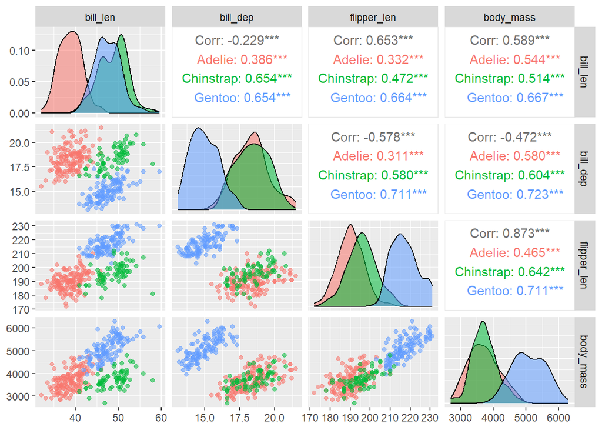

```r
penguinsNoNull = na.omit(penguins)
ggpairs(penguinsNoNull, columns = c(3,4,5,6), mapping = aes(color = species, alpha = 0.5))
```

Flipper length and bill depth do a great job of separating Gentoos from Chinstraps and Addiles, but the last two are very close together. All the Bill length scatterplots do a better job of separating Gentoos and Addiles.

### Part b (4 points)

Run a scaled principal component analysis on the four quantitative variables using the `prcomp()` function. How much of the total variation in these variables is explained by the first two principal components? You can use the `summary()` function on your PCA to find this easily.

```r
compMod = prcomp(~ bill_len + bill_dep + flipper_len + body_mass, data = penguinsNoNull, scale. = TRUE)

summary(compMod)
```

```
Importance of components:
                          PC1    PC2     PC3     PC4
Standard deviation     1.6569 0.8821 0.60716 0.32846
Proportion of Variance 0.6863 0.1945 0.09216 0.02697
Cumulative Proportion  0.6863 0.8809 0.97303 1.00000
```

88% of the variance is explained by 2 principal components

### Part c (6 points)

Plot the first two principal components with PC1 on the x-axis and PC2 on the y-axis. Color the points by species and comment on how well the first two principal components are separating by species.

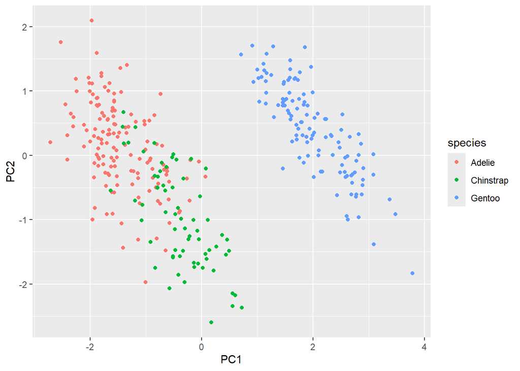

```r
PCs = (compMod$x)
penguinsPC = mutate(penguinsNoNull,PC1 = PCs[,1], PC2 = PCs[,2])
ggplot(penguinsPC, aes(x = PC1, y = PC2)) +
        geom_point(aes(color = species))
```

The first two principal components easily separate Gentoos from the rest, but Adelie and Chinstrap are still fairly intertwined.

### Part d (12 points)

Now use the `umap()` function in the `umap` library to fit a UMAP to the **scaled** quantitative variables in the penguins dataset. You can use the `scale()` function to scale the variables. Make sure the UMAP gives two components and set a `random_state` in the function so your results are reproducible. Then plot the UMAP using the the `umap_plot()` function in `math3190package` and color the points by `species` using the `color_umap` argument. Experiment with at least three different number of neighbors (`n_neighbors`) and at least three different minimum distances (`min_dist`).

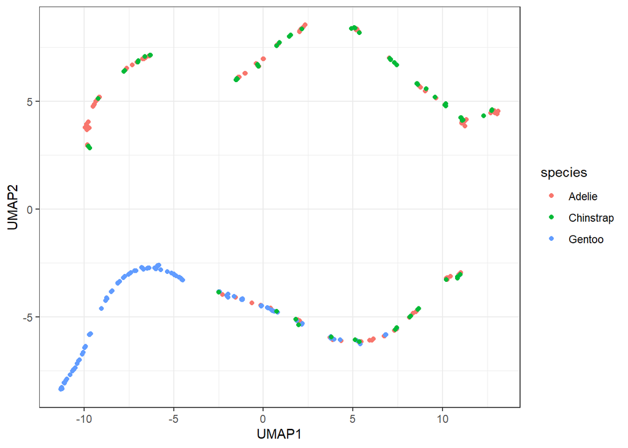

```r
scaled = mutate(penguinsNoNull, bill_len = scale(bill_len), bill_dep  = scale(bill_dep), flipper_len  = scale(flipper_len), body_mass  = scale(body_mass))
scaledX = select(penguinsNoNull, bill_len, bill_dep, flipper_len, body_mass)

#default with k = 15 min_dist = 0.1
penguinMap = umap(scaledX, random_state = 9000)
umap_plot(penguinMap,penguinsNoNull,color_umap = "species")
```

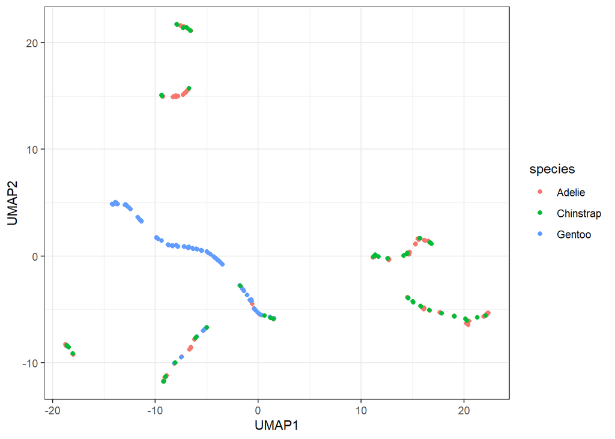

```r
# k = 10
penguinMap = umap(scaledX, random_state = 9000, n_neighbors = 10)
umap_plot(penguinMap,penguinsNoNull,color_umap = "species")
```

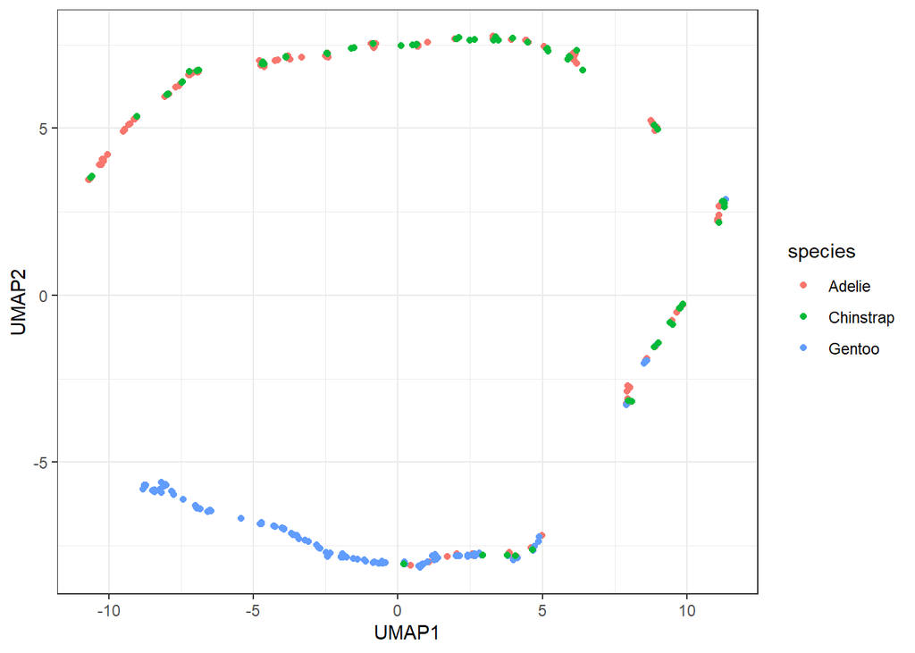

```r
#k = 25
penguinMap = umap(scaledX, random_state = 9000, n_neighbors = 25)
umap_plot(penguinMap,penguinsNoNull,color_umap = "species")
```

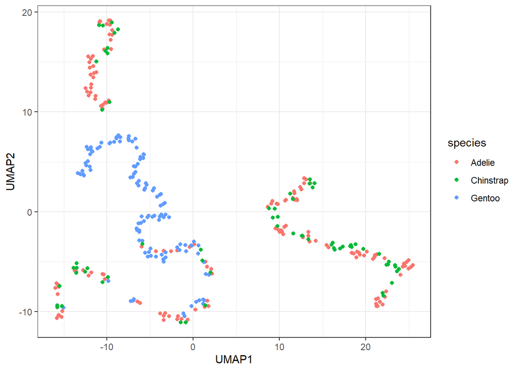

```r
#k=10 min_dist = 0.9
penguinMap = umap(scaledX, random_state = 9000, n_neighbors = 10, min_dist = 0.9)
umap_plot(penguinMap,penguinsNoNull,color_umap = "species")
```

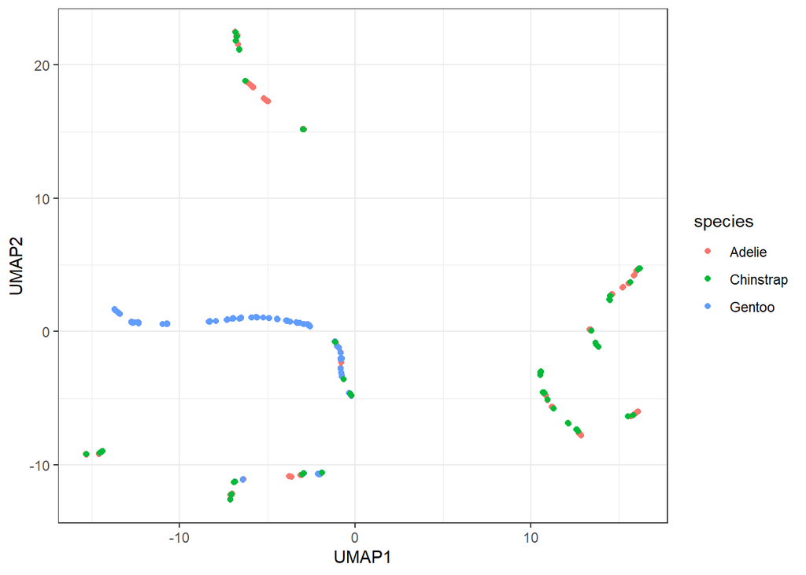

```r
#k=10 min_dist = 0.01
penguinMap = umap(scaledX, random_state = 9000, n_neighbors = 10, min_dist = 0.01)
umap_plot(penguinMap,penguinsNoNull,color_umap = "species")
```

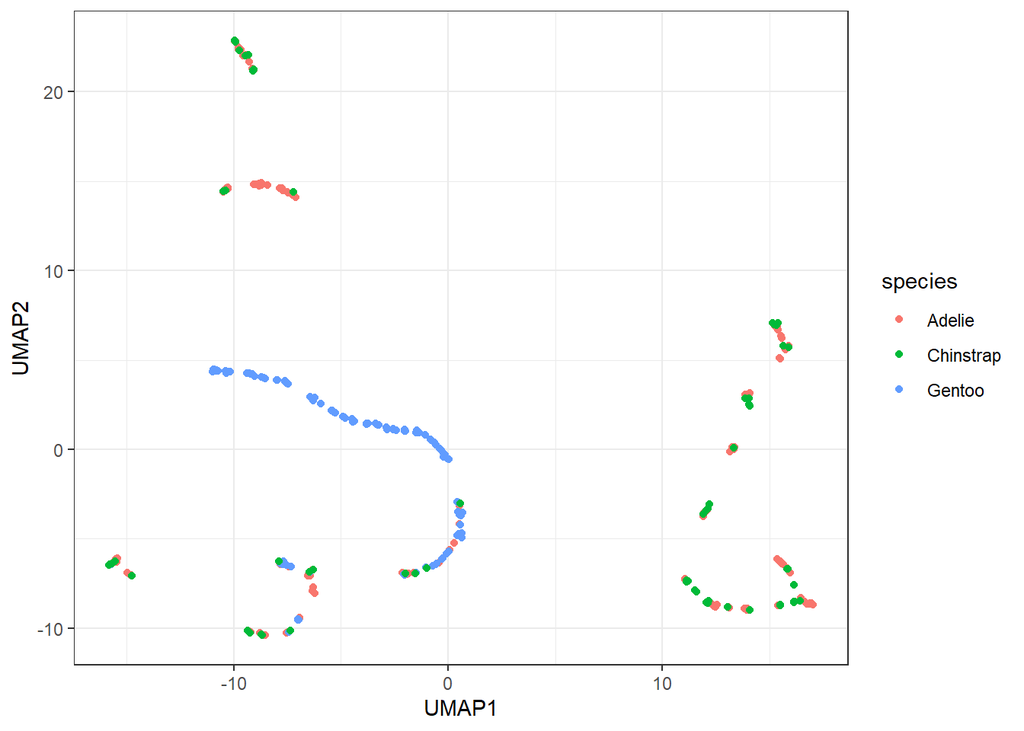

```r
#k=10 min_dist = 0.5
penguinMap = umap(scaledX, random_state = 9000, n_neighbors = 10, min_dist = 0.2)
umap_plot(penguinMap,penguinsNoNull,color_umap = "species")
```

### Part e (5 points)

Comment on the UMAP plots you made in part (d). Include a comparison to the PCA plot regarding how well these species are separated.

Feel free to repeat this problem using a variable other than species! Sometimes the UMAP outperforms PCA at separating classes, sometimes it does a little worse, and sometimes they are both quite bad. Unfortunately this seems to be the case here.